# customerSegmentation

```python
import pandas as pd
import seaborn as sns
import matplotlib.pyplot as plt

from sklearn.preprocessing import StandardScaler
from sklearn.cluster import KMeans
from sklearn.metrics import silhouette_score
```

```python
data = pd.read_excel("../data/online_retail_II.xlsx")
```

```python
df = data
```

```python
df.head()
```

|  | Invoice | StockCode | Description | Quantity | InvoiceDate | Price | Customer ID | Country |
| --- | --- | --- | --- | --- | --- | --- | --- | --- |
| 0 | 489434 | 85048 | 15CM CHRISTMAS GLASS BALL 20 LIGHTS | 12 | 2009-12-01 07:45:00 | 6.95 | 13085.0 | United Kingdom |
| 1 | 489434 | 79323P | PINK CHERRY LIGHTS | 12 | 2009-12-01 07:45:00 | 6.75 | 13085.0 | United Kingdom |
| 2 | 489434 | 79323W | WHITE CHERRY LIGHTS | 12 | 2009-12-01 07:45:00 | 6.75 | 13085.0 | United Kingdom |
| 3 | 489434 | 22041 | RECORD FRAME 7" SINGLE SIZE | 48 | 2009-12-01 07:45:00 | 2.10 | 13085.0 | United Kingdom |
| 4 | 489434 | 21232 | STRAWBERRY CERAMIC TRINKET BOX | 24 | 2009-12-01 07:45:00 | 1.25 | 13085.0 | United Kingdom |

### EXPLORATORY DATA ANALYSIS

```python
df.info()
```

```
<class 'pandas.DataFrame'>
RangeIndex: 525461 entries, 0 to 525460
Data columns (total 8 columns):
 #   Column       Non-Null Count   Dtype
---  ------       --------------   -----
 0   Invoice      525461 non-null  object
 1   StockCode    525461 non-null  object
 2   Description  522533 non-null  object
 3   Quantity     525461 non-null  int64
 4   InvoiceDate  525461 non-null  datetime64[us]
 5   Price        525461 non-null  float64
 6   Customer ID  417534 non-null  float64
 7   Country      525461 non-null  str
dtypes: datetime64[us](1), float64(2), int64(1), object(3), str(1)
memory usage: 32.1+ MB
```

```python
df.isna().sum()
```

```
Invoice             0
StockCode           0
Description      2928
Quantity            0
InvoiceDate         0
Price               0
Customer ID    107927
Country             0
dtype: int64
```

There are some missing values present in the dataset.

```python
df.describe()
```

|  | Quantity | InvoiceDate | Price | Customer ID |
| --- | --- | --- | --- | --- |
| count | 525461.000000 | 525461 | 525461.000000 | 417534.000000 |
| mean | 10.337667 | 2010-06-28 11:37:36.845018 | 4.688834 | 15360.645478 |
| min | -9600.000000 | 2009-12-01 07:45:00 | -53594.360000 | 12346.000000 |
| 25% | 1.000000 | 2010-03-21 12:20:00 | 1.250000 | 13983.000000 |
| 50% | 3.000000 | 2010-07-06 09:51:00 | 2.100000 | 15311.000000 |
| 75% | 10.000000 | 2010-10-15 12:45:00 | 4.210000 | 16799.000000 |
| max | 19152.000000 | 2010-12-09 20:01:00 | 25111.090000 | 18287.000000 |
| std | 107.424110 | NaN | 146.126914 | 1680.811316 |

There are some negative values in Quantity and Price column which is not ideal. We will investigate it further.

```python
df.describe(include="O")
```

|  | Invoice | StockCode | Description | Country |
| --- | --- | --- | --- | --- |
| count | 525461 | 525461 | 522533 | 525461 |
| unique | 28816 | 4632 | 4681 | 40 |
| top | 537434 | 85123A | WHITE HANGING HEART T-LIGHT HOLDER | United Kingdom |
| freq | 675 | 3516 | 3549 | 485852 |

```python
df[df["Customer ID"].isna()].head(10)
```

|  | Invoice | StockCode | Description | Quantity | InvoiceDate | Price | Customer ID | Country |
| --- | --- | --- | --- | --- | --- | --- | --- | --- |
| 263 | 489464 | 21733 | 85123a mixed | -96 | 2009-12-01 10:52:00 | 0.00 | NaN | United Kingdom |
| 283 | 489463 | 71477 | short | -240 | 2009-12-01 10:52:00 | 0.00 | NaN | United Kingdom |
| 284 | 489467 | 85123A | 21733 mixed | -192 | 2009-12-01 10:53:00 | 0.00 | NaN | United Kingdom |
| 470 | 489521 | 21646 | NaN | -50 | 2009-12-01 11:44:00 | 0.00 | NaN | United Kingdom |
| 577 | 489525 | 85226C | BLUE PULL BACK RACING CAR | 1 | 2009-12-01 11:49:00 | 0.55 | NaN | United Kingdom |
| 578 | 489525 | 85227 | SET/6 3D KIT CARDS FOR KIDS | 1 | 2009-12-01 11:49:00 | 0.85 | NaN | United Kingdom |
| 1055 | 489548 | 22271 | FELTCRAFT DOLL ROSIE | 1 | 2009-12-01 12:32:00 | 2.95 | NaN | United Kingdom |
| 1056 | 489548 | 22254 | FELT TOADSTOOL LARGE | 12 | 2009-12-01 12:32:00 | 1.25 | NaN | United Kingdom |
| 1057 | 489548 | 22273 | FELTCRAFT DOLL MOLLY | 3 | 2009-12-01 12:32:00 | 2.95 | NaN | United Kingdom |
| 1058 | 489548 | 22195 | LARGE HEART MEASURING SPOONS | 1 | 2009-12-01 12:32:00 | 1.65 | NaN | United Kingdom |

When we dont have a customer, there is no point trying to cluster that record. So we will eventually drop these columns where customer ID is missing.

```python
df[df["Quantity"] < 0].head(10)
```

|  | Invoice | StockCode | Description | Quantity | InvoiceDate | Price | Customer ID | Country |
| --- | --- | --- | --- | --- | --- | --- | --- | --- |
| 178 | C489449 | 22087 | PAPER BUNTING WHITE LACE | -12 | 2009-12-01 10:33:00 | 2.95 | 16321.0 | Australia |
| 179 | C489449 | 85206A | CREAM FELT EASTER EGG BASKET | -6 | 2009-12-01 10:33:00 | 1.65 | 16321.0 | Australia |
| 180 | C489449 | 21895 | POTTING SHED SOW 'N' GROW SET | -4 | 2009-12-01 10:33:00 | 4.25 | 16321.0 | Australia |
| 181 | C489449 | 21896 | POTTING SHED TWINE | -6 | 2009-12-01 10:33:00 | 2.10 | 16321.0 | Australia |
| 182 | C489449 | 22083 | PAPER CHAIN KIT RETRO SPOT | -12 | 2009-12-01 10:33:00 | 2.95 | 16321.0 | Australia |
| 183 | C489449 | 21871 | SAVE THE PLANET MUG | -12 | 2009-12-01 10:33:00 | 1.25 | 16321.0 | Australia |
| 184 | C489449 | 84946 | ANTIQUE SILVER TEA GLASS ETCHED | -12 | 2009-12-01 10:33:00 | 1.25 | 16321.0 | Australia |
| 185 | C489449 | 84970S | HANGING HEART ZINC T-LIGHT HOLDER | -24 | 2009-12-01 10:33:00 | 0.85 | 16321.0 | Australia |
| 186 | C489449 | 22090 | PAPER BUNTING RETRO SPOTS | -12 | 2009-12-01 10:33:00 | 2.95 | 16321.0 | Australia |
| 196 | C489459 | 90200A | PURPLE SWEETHEART BRACELET | -3 | 2009-12-01 10:44:00 | 4.25 | 17592.0 | United Kingdom |

The dataset described that if the invoice start with "C", it means its a cancelled order

```python
df['Invoice'].nunique()
```

```
28816
```

Lets identify if all the entries in the invoice column obey the laws of dataset description where the number must be 6 digits long and there can either be a "C" or nothing on the front.

```python
df["Invoice"] = df["Invoice"].astype("str")
```

```python
df[df["Invoice"].str.match("^C?\d{6}$") == True]
```

|  | Invoice | StockCode | Description | Quantity | InvoiceDate | Price | Customer ID | Country |
| --- | --- | --- | --- | --- | --- | --- | --- | --- |
| 0 | 489434 | 85048 | 15CM CHRISTMAS GLASS BALL 20 LIGHTS | 12 | 2009-12-01 07:45:00 | 6.95 | 13085.0 | United Kingdom |
| 1 | 489434 | 79323P | PINK CHERRY LIGHTS | 12 | 2009-12-01 07:45:00 | 6.75 | 13085.0 | United Kingdom |
| 2 | 489434 | 79323W | WHITE CHERRY LIGHTS | 12 | 2009-12-01 07:45:00 | 6.75 | 13085.0 | United Kingdom |
| 3 | 489434 | 22041 | RECORD FRAME 7" SINGLE SIZE | 48 | 2009-12-01 07:45:00 | 2.10 | 13085.0 | United Kingdom |
| 4 | 489434 | 21232 | STRAWBERRY CERAMIC TRINKET BOX | 24 | 2009-12-01 07:45:00 | 1.25 | 13085.0 | United Kingdom |
| ... | ... | ... | ... | ... | ... | ... | ... | ... |
| 525456 | 538171 | 22271 | FELTCRAFT DOLL ROSIE | 2 | 2010-12-09 20:01:00 | 2.95 | 17530.0 | United Kingdom |
| 525457 | 538171 | 22750 | FELTCRAFT PRINCESS LOLA DOLL | 1 | 2010-12-09 20:01:00 | 3.75 | 17530.0 | United Kingdom |
| 525458 | 538171 | 22751 | FELTCRAFT PRINCESS OLIVIA DOLL | 1 | 2010-12-09 20:01:00 | 3.75 | 17530.0 | United Kingdom |
| 525459 | 538171 | 20970 | PINK FLORAL FELTCRAFT SHOULDER BAG | 2 | 2010-12-09 20:01:00 | 3.75 | 17530.0 | United Kingdom |
| 525460 | 538171 | 21931 | JUMBO STORAGE BAG SUKI | 2 | 2010-12-09 20:01:00 | 1.95 | 17530.0 | United Kingdom |

525458 rows × 8 columns

```python
df[df["Invoice"].str.match("^C?\d{6}$") == False]
```

|  | Invoice | StockCode | Description | Quantity | InvoiceDate | Price | Customer ID | Country |
| --- | --- | --- | --- | --- | --- | --- | --- | --- |
| 179403 | A506401 | B | Adjust bad debt | 1 | 2010-04-29 13:36:00 | -53594.36 | NaN | United Kingdom |
| 276274 | A516228 | B | Adjust bad debt | 1 | 2010-07-19 11:24:00 | -44031.79 | NaN | United Kingdom |
| 403472 | A528059 | B | Adjust bad debt | 1 | 2010-10-20 12:04:00 | -38925.87 | NaN | United Kingdom |

These are some sort of balancing the accounts debts.

```python
incorrect_stockcode = df[df["StockCode"].str.match("^\d{5}$") == False]
```

```python
incorrect_stockcode.shape
```

```
(80112, 8)
```

These appear to be ligit transactions as the price and customer ids are available. As nothing is mentioned in the dataset about this, we are going to consider this ligit and proceed with them.

```python
df[df["StockCode"] == "PADS"]
```

|  | Invoice | StockCode | Description | Quantity | InvoiceDate | Price | Customer ID | Country |
| --- | --- | --- | --- | --- | --- | --- | --- | --- |
| 62299 | 494914 | PADS | PADS TO MATCH ALL CUSHIONS | 1 | 2010-01-19 17:04:00 | 0.001 | 16705.0 | United Kingdom |
| 74731 | 496222 | PADS | PADS TO MATCH ALL CUSHIONS | 1 | 2010-01-29 13:53:00 | 0.001 | 13583.0 | United Kingdom |
| 77702 | 496473 | PADS | PADS TO MATCH ALL CUSHIONS | 1 | 2010-02-01 15:38:00 | 0.001 | 17350.0 | United Kingdom |
| 79794 | 496643 | PADS | PADS TO MATCH ALL CUSHIONS | 1 | 2010-02-03 11:58:00 | 0.001 | 13408.0 | United Kingdom |
| 90798 | 497935 | PADS | PADS TO MATCH ALL CUSHIONS | 1 | 2010-02-15 10:47:00 | 0.001 | 13408.0 | United Kingdom |
| 97716 | 498562 | PADS | PADS TO MATCH ALL CUSHIONS | 1 | 2010-02-21 12:03:00 | 0.001 | 15182.0 | United Kingdom |
| 101718 | 499056 | PADS | PADS TO MATCH ALL CUSHIONS | 1 | 2010-02-24 13:46:00 | 0.001 | 13765.0 | United Kingdom |
| 104480 | 499399 | PADS | PADS TO MATCH ALL CUSHIONS | 1 | 2010-02-26 13:26:00 | 0.001 | 14459.0 | United Kingdom |
| 123947 | 501176 | PADS | PADS TO MATCH ALL CUSHIONS | 1 | 2010-03-15 11:00:00 | 0.001 | 14857.0 | United Kingdom |
| 156809 | 504332 | PADS | PADS TO MATCH ALL CUSHIONS | 1 | 2010-04-12 16:30:00 | 0.001 | 12671.0 | Germany |
| 178629 | 506303 | PADS | PADS TO MATCH ALL CUSHIONS | 1 | 2010-04-29 10:43:00 | 0.001 | 14249.0 | United Kingdom |
| 249035 | C513477 | PADS | PADS TO MATCH ALL CUSHIONS | -1 | 2010-06-24 16:56:00 | 36.600 | 14459.0 | United Kingdom |
| 341826 | 522766 | PADS | PADS TO MATCH ALL CUSHIONS | 1 | 2010-09-16 13:58:00 | 0.001 | 15182.0 | United Kingdom |
| 440930 | 531433 | PADS | PADS TO MATCH ALL CUSHIONS | 1 | 2010-11-08 11:54:00 | 0.001 | 13317.0 | United Kingdom |
| 468280 | 533528 | PADS | PADS TO MATCH ALL CUSHIONS | 1 | 2010-11-17 15:08:00 | 0.001 | 15750.0 | United Kingdom |

What if we just drop the customer ID missing columns and check that how many of these values are eliminated.

```python
missing_customer_id = df[df['Customer ID'].isna()]
```

```python
missing_customer_id.shape
```

```
(107927, 8)
```

```python
incorrect_stockcode["StockCode"].isin(missing_customer_id['StockCode']).sum()
```

```
np.int64(79137)
```

It appears that majority of the entries that have an incorrect stockcode is majorly a business entry and not a customer entry as they are missing the customer ids in the dataset.

### DATA CLEANING

```python
cleaned_df = df.copy()
```

```python
# Clean the Invoice column

cleaned_df["Invoice"] = cleaned_df["Invoice"].astype("str")

mask = (
    cleaned_df["Invoice"].str.match("^\\d{6}$") == True
)

cleaned_df = cleaned_df[mask]

cleaned_df
```

|  | Invoice | StockCode | Description | Quantity | InvoiceDate | Price | Customer ID | Country |
| --- | --- | --- | --- | --- | --- | --- | --- | --- |
| 0 | 489434 | 85048 | 15CM CHRISTMAS GLASS BALL 20 LIGHTS | 12 | 2009-12-01 07:45:00 | 6.95 | 13085.0 | United Kingdom |
| 1 | 489434 | 79323P | PINK CHERRY LIGHTS | 12 | 2009-12-01 07:45:00 | 6.75 | 13085.0 | United Kingdom |
| 2 | 489434 | 79323W | WHITE CHERRY LIGHTS | 12 | 2009-12-01 07:45:00 | 6.75 | 13085.0 | United Kingdom |
| 3 | 489434 | 22041 | RECORD FRAME 7" SINGLE SIZE | 48 | 2009-12-01 07:45:00 | 2.10 | 13085.0 | United Kingdom |
| 4 | 489434 | 21232 | STRAWBERRY CERAMIC TRINKET BOX | 24 | 2009-12-01 07:45:00 | 1.25 | 13085.0 | United Kingdom |
| ... | ... | ... | ... | ... | ... | ... | ... | ... |
| 525456 | 538171 | 22271 | FELTCRAFT DOLL ROSIE | 2 | 2010-12-09 20:01:00 | 2.95 | 17530.0 | United Kingdom |
| 525457 | 538171 | 22750 | FELTCRAFT PRINCESS LOLA DOLL | 1 | 2010-12-09 20:01:00 | 3.75 | 17530.0 | United Kingdom |
| 525458 | 538171 | 22751 | FELTCRAFT PRINCESS OLIVIA DOLL | 1 | 2010-12-09 20:01:00 | 3.75 | 17530.0 | United Kingdom |
| 525459 | 538171 | 20970 | PINK FLORAL FELTCRAFT SHOULDER BAG | 2 | 2010-12-09 20:01:00 | 3.75 | 17530.0 | United Kingdom |
| 525460 | 538171 | 21931 | JUMBO STORAGE BAG SUKI | 2 | 2010-12-09 20:01:00 | 1.95 | 17530.0 | United Kingdom |

515252 rows × 8 columns

```python
# Clean The StockCode column

cleaned_df["StockCode"] = cleaned_df["StockCode"].astype("str")

mask = (
    (cleaned_df["StockCode"].str.match("^\\d{5}$") == True)
    | (cleaned_df["StockCode"].str.match("^\\d{5}[a-zA-Z]+$") == True)
    | (cleaned_df["StockCode"].str.match("^PADS$") == True)
)

cleaned_df = cleaned_df[mask]

cleaned_df
```

|  | Invoice | StockCode | Description | Quantity | InvoiceDate | Price | Customer ID | Country |
| --- | --- | --- | --- | --- | --- | --- | --- | --- |
| 0 | 489434 | 85048 | 15CM CHRISTMAS GLASS BALL 20 LIGHTS | 12 | 2009-12-01 07:45:00 | 6.95 | 13085.0 | United Kingdom |
| 1 | 489434 | 79323P | PINK CHERRY LIGHTS | 12 | 2009-12-01 07:45:00 | 6.75 | 13085.0 | United Kingdom |
| 2 | 489434 | 79323W | WHITE CHERRY LIGHTS | 12 | 2009-12-01 07:45:00 | 6.75 | 13085.0 | United Kingdom |
| 3 | 489434 | 22041 | RECORD FRAME 7" SINGLE SIZE | 48 | 2009-12-01 07:45:00 | 2.10 | 13085.0 | United Kingdom |
| 4 | 489434 | 21232 | STRAWBERRY CERAMIC TRINKET BOX | 24 | 2009-12-01 07:45:00 | 1.25 | 13085.0 | United Kingdom |
| ... | ... | ... | ... | ... | ... | ... | ... | ... |
| 525456 | 538171 | 22271 | FELTCRAFT DOLL ROSIE | 2 | 2010-12-09 20:01:00 | 2.95 | 17530.0 | United Kingdom |
| 525457 | 538171 | 22750 | FELTCRAFT PRINCESS LOLA DOLL | 1 | 2010-12-09 20:01:00 | 3.75 | 17530.0 | United Kingdom |
| 525458 | 538171 | 22751 | FELTCRAFT PRINCESS OLIVIA DOLL | 1 | 2010-12-09 20:01:00 | 3.75 | 17530.0 | United Kingdom |
| 525459 | 538171 | 20970 | PINK FLORAL FELTCRAFT SHOULDER BAG | 2 | 2010-12-09 20:01:00 | 3.75 | 17530.0 | United Kingdom |
| 525460 | 538171 | 21931 | JUMBO STORAGE BAG SUKI | 2 | 2010-12-09 20:01:00 | 1.95 | 17530.0 | United Kingdom |

512796 rows × 8 columns

```python
cleaned_df.describe()
```

|  | Quantity | InvoiceDate | Price | Customer ID |
| --- | --- | --- | --- | --- |
| count | 512796.000000 | 512796 | 512796.000000 | 406337.000000 |
| mean | 11.001279 | 2010-06-28 18:26:52.709732 | 3.391447 | 15373.632992 |
| min | -9600.000000 | 2009-12-01 07:45:00 | 0.000000 | 12346.000000 |
| 25% | 1.000000 | 2010-03-21 13:27:00 | 1.250000 | 14004.000000 |
| 50% | 3.000000 | 2010-07-06 14:25:00 | 2.100000 | 15326.000000 |
| 75% | 10.000000 | 2010-10-15 14:50:00 | 4.210000 | 16814.000000 |
| max | 19152.000000 | 2010-12-09 20:01:00 | 1157.150000 | 18287.000000 |
| std | 104.352433 | NaN | 5.067864 | 1677.365907 |

```python
# Clean the customer id column

cleaned_df.dropna(subset="Customer ID", inplace=True)
```

```python
cleaned_df.describe()
```

|  | Quantity | InvoiceDate | Price | Customer ID |
| --- | --- | --- | --- | --- |
| count | 406337.000000 | 406337 | 406337.000000 | 406337.000000 |
| mean | 13.619099 | 2010-07-01 10:11:06.543287 | 2.991462 | 15373.632992 |
| min | 1.000000 | 2009-12-01 07:45:00 | 0.000000 | 12346.000000 |
| 25% | 2.000000 | 2010-03-26 14:01:00 | 1.250000 | 14004.000000 |
| 50% | 5.000000 | 2010-07-09 15:48:00 | 1.950000 | 15326.000000 |
| 75% | 12.000000 | 2010-10-14 17:09:00 | 3.750000 | 16814.000000 |
| max | 19152.000000 | 2010-12-09 20:01:00 | 295.000000 | 18287.000000 |
| std | 97.000659 | NaN | 4.285876 | 1677.365907 |

Quantity is also solved. Lets look at price problem.

```python
len(cleaned_df[cleaned_df["Price"] == 0])
```

```
28
```

0 Priced item must be not be included in a sensible analysis, and as these transactions are only 28 we can drop them.

```python
cleaned_df = cleaned_df[cleaned_df['Price'] > 0]
```

```python
cleaned_df.describe()
```

|  | Quantity | InvoiceDate | Price | Customer ID |
| --- | --- | --- | --- | --- |
| count | 406309.000000 | 406309 | 406309.000000 | 406309.000000 |
| mean | 13.617924 | 2010-07-01 10:14:25.869572 | 2.991668 | 15373.722268 |
| min | 1.000000 | 2009-12-01 07:45:00 | 0.001000 | 12346.000000 |
| 25% | 2.000000 | 2010-03-26 14:01:00 | 1.250000 | 14006.000000 |
| 50% | 5.000000 | 2010-07-09 15:48:00 | 1.950000 | 15326.000000 |
| 75% | 12.000000 | 2010-10-14 17:09:00 | 3.750000 | 16814.000000 |
| max | 19152.000000 | 2010-12-09 20:01:00 | 295.000000 | 18287.000000 |
| std | 96.998833 | NaN | 4.285951 | 1677.329470 |

How much data did we loose during our cleaning proceed ?

```python
current_data = round(len(cleaned_df) * 100 / len(df))
lost_data = round(100 - current_data)

print("Current Data: ", current_data)
print("Lost Data: ", lost_data )
```

```
Current Data:  77
Lost Data:  23
```

Dropped Almost 23% of entire records.

### FEATURE ENGINEERING

We will create some columns for Measureing RFM for all the customers.

```python
cleaned_df['TotalAmount'] = cleaned_df["Quantity"] * cleaned_df['Price']
cleaned_df.head()
```

|  | Invoice | StockCode | Description | Quantity | InvoiceDate | Price | Customer ID | Country | TotalAmount |
| --- | --- | --- | --- | --- | --- | --- | --- | --- | --- |
| 0 | 489434 | 85048 | 15CM CHRISTMAS GLASS BALL 20 LIGHTS | 12 | 2009-12-01 07:45:00 | 6.95 | 13085.0 | United Kingdom | 83.4 |
| 1 | 489434 | 79323P | PINK CHERRY LIGHTS | 12 | 2009-12-01 07:45:00 | 6.75 | 13085.0 | United Kingdom | 81.0 |
| 2 | 489434 | 79323W | WHITE CHERRY LIGHTS | 12 | 2009-12-01 07:45:00 | 6.75 | 13085.0 | United Kingdom | 81.0 |
| 3 | 489434 | 22041 | RECORD FRAME 7" SINGLE SIZE | 48 | 2009-12-01 07:45:00 | 2.10 | 13085.0 | United Kingdom | 100.8 |
| 4 | 489434 | 21232 | STRAWBERRY CERAMIC TRINKET BOX | 24 | 2009-12-01 07:45:00 | 1.25 | 13085.0 | United Kingdom | 30.0 |

Now we will bring our data on customer level by aggregating so that we can calculate RFM for different customers.

```python
aggregated_df = cleaned_df.groupby("Customer ID", as_index=False) \
        .agg(
            MonetaryValue = ("TotalAmount", "sum"),
            Frequency=("Invoice", "nunique"),
            LastInvoiceDate =("InvoiceDate", "max")
        )

aggregated_df
```

|  | Customer ID | MonetaryValue | Frequency | LastInvoiceDate |
| --- | --- | --- | --- | --- |
| 0 | 12346.0 | 169.36 | 2 | 2010-06-28 13:53:00 |
| 1 | 12347.0 | 1323.32 | 2 | 2010-12-07 14:57:00 |
| 2 | 12348.0 | 221.16 | 1 | 2010-09-27 14:59:00 |
| 3 | 12349.0 | 2221.14 | 2 | 2010-10-28 08:23:00 |
| 4 | 12351.0 | 300.93 | 1 | 2010-11-29 15:23:00 |
| ... | ... | ... | ... | ... |
| 4280 | 18283.0 | 641.77 | 6 | 2010-11-22 15:30:00 |
| 4281 | 18284.0 | 411.68 | 1 | 2010-10-04 11:33:00 |
| 4282 | 18285.0 | 377.00 | 1 | 2010-02-17 10:24:00 |
| 4283 | 18286.0 | 1246.43 | 2 | 2010-08-20 11:57:00 |
| 4284 | 18287.0 | 2295.71 | 4 | 2010-11-22 11:51:00 |

4285 rows × 4 columns

```python
max_invoice_date = aggregated_df["LastInvoiceDate"].max()

max_invoice_date
```

```
Timestamp('2010-12-09 20:01:00')
```

In real implementation we usually take the todays data as that makes more sense.

```python
aggregated_df["RecencyValue"] = (max_invoice_date - aggregated_df['LastInvoiceDate']).dt.days
```

```python
aggregated_df
```

|  | Customer ID | MonetaryValue | Frequency | LastInvoiceDate | RecencyValue |
| --- | --- | --- | --- | --- | --- |
| 0 | 12346.0 | 169.36 | 2 | 2010-06-28 13:53:00 | 164 |
| 1 | 12347.0 | 1323.32 | 2 | 2010-12-07 14:57:00 | 2 |
| 2 | 12348.0 | 221.16 | 1 | 2010-09-27 14:59:00 | 73 |
| 3 | 12349.0 | 2221.14 | 2 | 2010-10-28 08:23:00 | 42 |
| 4 | 12351.0 | 300.93 | 1 | 2010-11-29 15:23:00 | 10 |
| ... | ... | ... | ... | ... | ... |
| 4280 | 18283.0 | 641.77 | 6 | 2010-11-22 15:30:00 | 17 |
| 4281 | 18284.0 | 411.68 | 1 | 2010-10-04 11:33:00 | 66 |
| 4282 | 18285.0 | 377.00 | 1 | 2010-02-17 10:24:00 | 295 |
| 4283 | 18286.0 | 1246.43 | 2 | 2010-08-20 11:57:00 | 111 |
| 4284 | 18287.0 | 2295.71 | 4 | 2010-11-22 11:51:00 | 17 |

4285 rows × 5 columns

### Visualization

```python
help(sns.histplot)
```

[output not shown]

[output cut: 145 more lines]

[output not shown]

#### HISTOGRAMS

1. Monetary Value

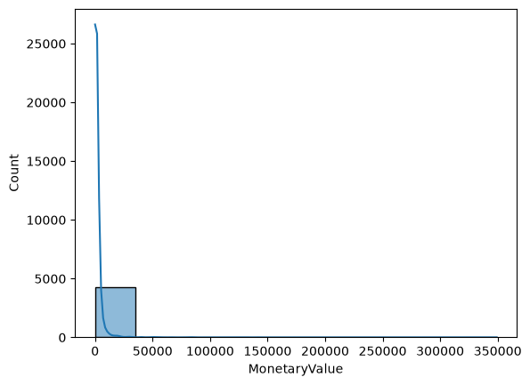

```python
sns.histplot(
    data=aggregated_df,
    x="MonetaryValue",
    bins=10,
    kde=True
)

plt.show()
```

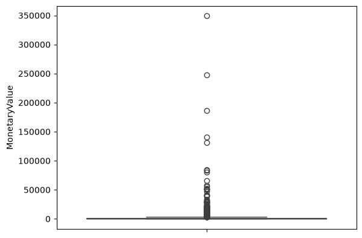

```python
sns.boxplot(
    data=aggregated_df,
    y="MonetaryValue"
)

plt.show()
```

There are so many outliers present in Monetary Value column.

2. Frequency Value

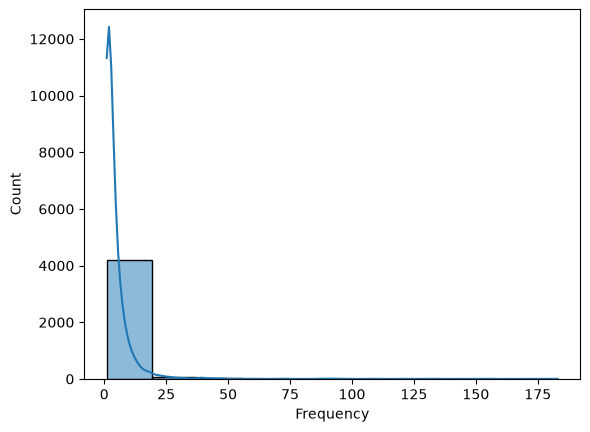

```python
sns.histplot(
    data=aggregated_df,
    x="Frequency",
    bins=10,
    kde=True
)

plt.show()
```

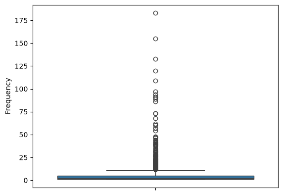

```python
sns.boxplot(
    data=aggregated_df,
    y="Frequency"
)

plt.show()
```

There are several outliers present in this column as well. We will look into this later on.

3. Recency Value

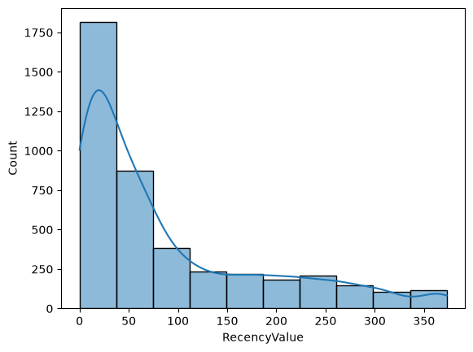

```python
sns.histplot(
    data=aggregated_df,
    x="RecencyValue",
    bins=10,
    kde=True
)

plt.show()
```

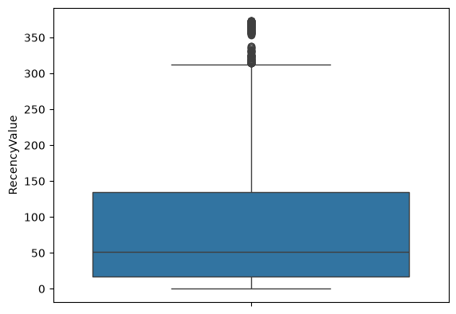

```python
sns.boxplot(
    data=aggregated_df,
    y='RecencyValue'
)

plt.show()
```

There are considerably lesser outliers in this column compared to the other two.

Now as for analysism, we cant simply remove these outliers as these are the most valuable customers in our business problem.

But Outliers are bad for Clustering problem as well. So we will perform the clustering on general customers and perform seperate analysis on outliers.

Lets get hold of the outliers data.

```python
# Monetary Outliers

M_Q3 = aggregated_df['MonetaryValue'].quantile(0.75)
M_Q1 = aggregated_df['MonetaryValue'].quantile(0.25)
M_IQR = M_Q3 - M_Q1

M_UL = M_Q3 + (1.5 * M_IQR)
M_LL = M_Q1 - (1.5 * M_IQR)

M_outliers = aggregated_df[(aggregated_df['MonetaryValue'] > M_UL) | (aggregated_df["MonetaryValue"] < M_LL)]

M_outliers.head()
```

|  | Customer ID | MonetaryValue | Frequency | LastInvoiceDate | RecencyValue |
| --- | --- | --- | --- | --- | --- |
| 9 | 12357.0 | 11229.99 | 1 | 2010-11-16 10:05:00 | 23 |
| 25 | 12380.0 | 4782.84 | 4 | 2010-08-31 14:54:00 | 100 |
| 42 | 12409.0 | 12346.62 | 4 | 2010-10-15 10:24:00 | 55 |
| 48 | 12415.0 | 19468.84 | 4 | 2010-11-29 15:07:00 | 10 |
| 61 | 12431.0 | 4145.52 | 11 | 2010-12-01 10:03:00 | 8 |

```python
M_outliers.describe()
```

|  | Customer ID | MonetaryValue | Frequency | LastInvoiceDate | RecencyValue |
| --- | --- | --- | --- | --- | --- |
| count | 423.000000 | 423.000000 | 423.000000 | 423 | 423.000000 |
| mean | 15103.040189 | 12188.101740 | 17.167849 | 2010-11-09 12:26:02.978723 | 30.035461 |
| min | 12357.000000 | 3802.040000 | 1.000000 | 2009-12-10 18:03:00 | 0.000000 |
| 25% | 13622.000000 | 4605.940000 | 8.000000 | 2010-11-08 13:17:30 | 3.000000 |
| 50% | 14961.000000 | 6191.320000 | 12.000000 | 2010-11-26 12:19:00 | 13.000000 |
| 75% | 16692.000000 | 10273.235000 | 18.000000 | 2010-12-06 10:34:30 | 31.000000 |
| max | 18260.000000 | 349164.350000 | 183.000000 | 2010-12-09 19:32:00 | 364.000000 |
| std | 1728.661406 | 25830.851045 | 19.729755 | NaN | 51.541004 |

```python
# Frequency Outliers

F_Q3 = aggregated_df['Frequency'].quantile(0.75)
F_Q1 = aggregated_df['Frequency'].quantile(0.25)
F_IQR = F_Q3 - F_Q1
F_UL = F_Q3 + (1.5 * F_IQR)
F_LL = F_Q3 - (1.5 * F_IQR)

F_outliers = aggregated_df[(aggregated_df['Frequency'] > F_UL) | (aggregated_df['Frequency'] < F_LL)]

F_outliers.head()
```

|  | Customer ID | MonetaryValue | Frequency | LastInvoiceDate | RecencyValue |
| --- | --- | --- | --- | --- | --- |
| 65 | 12437.0 | 6834.99 | 20 | 2010-11-09 14:46:00 | 30 |
| 84 | 12471.0 | 17721.45 | 44 | 2010-11-30 14:35:00 | 9 |
| 85 | 12472.0 | 10426.48 | 13 | 2010-12-05 14:19:00 | 4 |
| 92 | 12482.0 | 21941.72 | 27 | 2010-05-12 16:51:00 | 211 |
| 115 | 12523.0 | 2330.38 | 12 | 2010-11-30 12:31:00 | 9 |

```python
F_outliers.describe()
```

|  | Customer ID | MonetaryValue | Frequency | LastInvoiceDate | RecencyValue |
| --- | --- | --- | --- | --- | --- |
| count | 279.000000 | 279.000000 | 279.000000 | 279 | 279.000000 |
| mean | 15352.655914 | 14409.714932 | 23.810036 | 2010-11-23 11:06:20.645161 | 16.089606 |
| min | 12437.000000 | 1094.390000 | 12.000000 | 2010-05-12 16:51:00 | 0.000000 |
| 25% | 13800.000000 | 4331.560500 | 13.000000 | 2010-11-20 13:14:30 | 2.000000 |
| 50% | 15465.000000 | 6615.770000 | 17.000000 | 2010-12-02 10:46:00 | 7.000000 |
| 75% | 16828.500000 | 11692.405000 | 23.000000 | 2010-12-07 11:08:30 | 19.000000 |
| max | 18260.000000 | 349164.350000 | 183.000000 | 2010-12-09 19:32:00 | 211.000000 |
| std | 1748.429987 | 31381.736785 | 21.932937 | NaN | 26.589117 |

There can be an overlap between the outliers of Monetary value and the frequency value. We will look into it later on.

```python
# Non-Outliers data

non_outliers_df = aggregated_df[(~aggregated_df.index.isin(M_outliers.index)) & (~aggregated_df.index.isin(F_outliers.index))]

non_outliers_df.describe()
```

|  | Customer ID | MonetaryValue | Frequency | LastInvoiceDate | RecencyValue |
| --- | --- | --- | --- | --- | --- |
| count | 3809.000000 | 3809.000000 | 3809.000000 | 3809 | 3809.000000 |
| mean | 15376.482804 | 885.502197 | 2.863481 | 2010-09-03 11:16:46.516146 | 97.082174 |
| min | 12346.000000 | 1.550000 | 1.000000 | 2009-12-01 10:49:00 | 0.000000 |
| 25% | 13912.000000 | 279.910000 | 1.000000 | 2010-07-08 14:48:00 | 22.000000 |
| 50% | 15389.000000 | 588.050000 | 2.000000 | 2010-10-12 16:25:00 | 58.000000 |
| 75% | 16854.000000 | 1269.050000 | 4.000000 | 2010-11-17 13:14:00 | 154.000000 |
| max | 18287.000000 | 3788.210000 | 11.000000 | 2010-12-09 20:01:00 | 373.000000 |
| std | 1693.199806 | 817.672283 | 2.243748 | NaN | 98.111495 |

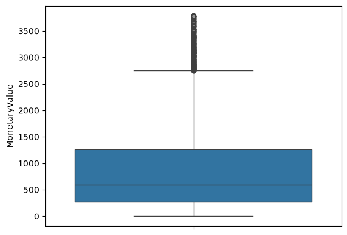

```python
sns.boxplot(
    data=non_outliers_df,
    y="MonetaryValue"
)

plt.show()
```

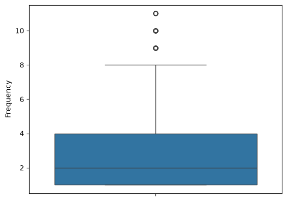

```python
sns.boxplot(
    data=non_outliers_df,
    y="Frequency"
)

plt.show()
```

Now the outliers are seem to be much more bearable.

Now, For Clustering we will be using K-Means Clustering Algorithm. K-Means clustering is a distance based algorithm where scales of different entities matter a lot.

So we will perform a Standard Scaling operation on the data.

```python
scaler = StandardScaler()

scaled_data = scaler.fit_transform(non_outliers_df[["MonetaryValue", "Frequency", "RecencyValue"]])

scaled_data
```

```
array([[-0.87594534, -0.38488934,  0.68214853],
       [ 0.5355144 , -0.38488934, -0.96925093],
       [-0.81258645, -0.83063076, -0.24548944],
       ...,
       [-0.62197163, -0.83063076,  2.01753946],
       [ 0.44146683, -0.38488934,  0.14187587],
       [ 1.72488781,  0.50659348, -0.81634357]], shape=(3809, 3))
```

We recieved a Numpy array here. We will convert this to a dataframe

```python
scaled_data_df = pd.DataFrame(scaled_data, index=non_outliers_df.index, columns = ['MonetaryValue', 'FrequencyValue', 'RecencyValue'])
```

```python
scaled_data_df
```

|  | MonetaryValue | FrequencyValue | RecencyValue |
| --- | --- | --- | --- |
| 0 | -0.875945 | -0.384889 | 0.682149 |
| 1 | 0.535514 | -0.384889 | -0.969251 |
| 2 | -0.812586 | -0.830631 | -0.245489 |
| 3 | 1.633678 | -0.384889 | -0.561498 |
| 4 | -0.715016 | -0.830631 | -0.887700 |
| ... | ... | ... | ... |
| 4280 | -0.298120 | 1.398076 | -0.816344 |
| 4281 | -0.579553 | -0.830631 | -0.316846 |
| 4282 | -0.621972 | -0.830631 | 2.017539 |
| 4283 | 0.441467 | -0.384889 | 0.141876 |
| 4284 | 1.724888 | 0.506593 | -0.816344 |

3809 rows × 3 columns

### K-Means Clustering

We will identify the value of K using the infamous "Elbow Method"

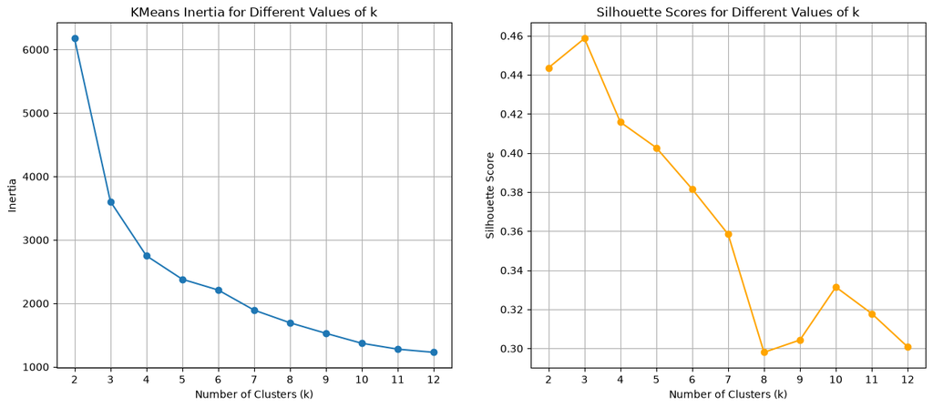

```python
max_k = 12

inertia = []
silhouette_scores =[]
k_vals = range(2, max_k + 1)

for k in k_vals:

    kmeans = KMeans(
        n_clusters=k,
        random_state=42,
        max_iter=1000
    )

    cluster_labels = kmeans.fit_predict(scaled_data_df)

    sil_score = silhouette_score(scaled_data_df, cluster_labels)

    silhouette_scores.append(sil_score)

    inertia.append(kmeans.inertia_)
plt.figure(figsize=(15,6))


plt.subplot(1, 2, 1)
plt.plot(k_vals, inertia, marker='o')
plt.title('KMeans Inertia for Different Values of k')
plt.xlabel('Number of Clusters (k)')
plt.ylabel('Inertia')
plt.xticks(k_vals)
plt.grid(True)

plt.subplot(1, 2, 2)
plt.plot(k_vals, silhouette_scores, marker='o', color='orange')
plt.title('Silhouette Scores for Different Values of k')
plt.xlabel('Number of Clusters (k)')
plt.ylabel('Silhouette Score')
plt.xticks(k_vals)
plt.grid(True)


plt.grid(True)
plt.show()
```

4,5 Appears to be best k Value using the elbow method. To determine the best one we will use another metric Which is the "Silhouette Score".

We can see that k=4 has better silhouette score. We will go ahead and use 4.

```python
# Final Model

kmeans = KMeans(
    n_clusters=4,
    random_state=42,
    max_iter=1000
)

cluster_labels = kmeans.fit_predict(scaled_data_df)

cluster_labels
```

```
array([1, 0, 2, ..., 1, 0, 0], shape=(3809,), dtype=int32)
```

Now, we have eaech customer assigned to one particular cluster.

### Cluster Analysis

```python
non_outliers_df["Cluster"] = cluster_labels

non_outliers_df
```

|  | Customer ID | MonetaryValue | Frequency | LastInvoiceDate | RecencyValue | Cluster |
| --- | --- | --- | --- | --- | --- | --- |
| 0 | 12346.0 | 169.36 | 2 | 2010-06-28 13:53:00 | 164 | 1 |
| 1 | 12347.0 | 1323.32 | 2 | 2010-12-07 14:57:00 | 2 | 0 |
| 2 | 12348.0 | 221.16 | 1 | 2010-09-27 14:59:00 | 73 | 2 |
| 3 | 12349.0 | 2221.14 | 2 | 2010-10-28 08:23:00 | 42 | 0 |
| 4 | 12351.0 | 300.93 | 1 | 2010-11-29 15:23:00 | 10 | 2 |
| ... | ... | ... | ... | ... | ... | ... |
| 4280 | 18283.0 | 641.77 | 6 | 2010-11-22 15:30:00 | 17 | 0 |
| 4281 | 18284.0 | 411.68 | 1 | 2010-10-04 11:33:00 | 66 | 2 |
| 4282 | 18285.0 | 377.00 | 1 | 2010-02-17 10:24:00 | 295 | 1 |
| 4283 | 18286.0 | 1246.43 | 2 | 2010-08-20 11:57:00 | 111 | 0 |
| 4284 | 18287.0 | 2295.71 | 4 | 2010-11-22 11:51:00 | 17 | 0 |

3809 rows × 6 columns

```python
non_outliers_df['Cluster'].unique()
```

```
array([1, 0, 2, 3], dtype=int32)
```

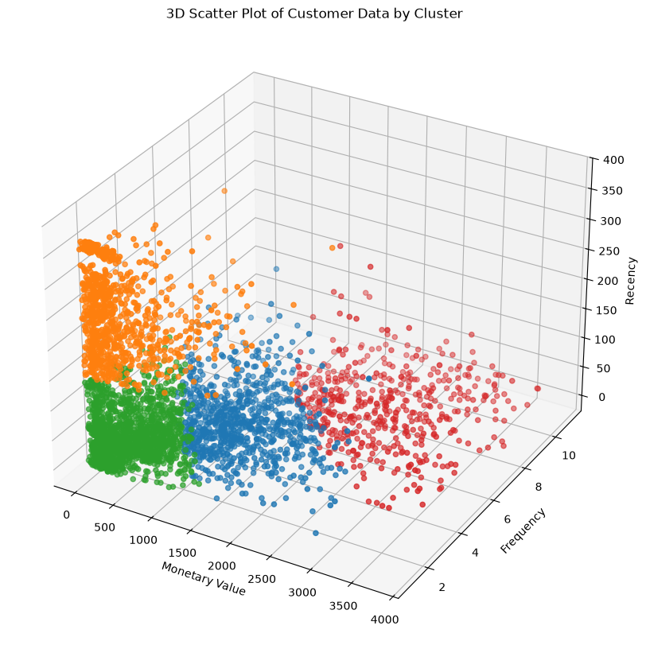

```python
cluster_colors = {
    0: '#1f77b4',  # Blue
    1: '#ff7f0e',  # Orange
    2: '#2ca02c',  # Green
    3: '#d62728'   # Red
}

colors = non_outliers_df['Cluster'].map(cluster_colors)

fig = plt.figure(figsize=(10, 10))
ax = fig.add_subplot(projection='3d')

scatter = ax.scatter(
    non_outliers_df['MonetaryValue'],
    non_outliers_df['Frequency'],
    non_outliers_df['RecencyValue'],
    c=colors,  # Use mapped solid colors
    marker='o'
)

ax.set_xlabel('Monetary Value')
ax.set_ylabel('Frequency')
ax.set_zlabel('Recency')

ax.set_title('3D Scatter Plot of Customer Data by Cluster')

plt.show()
```

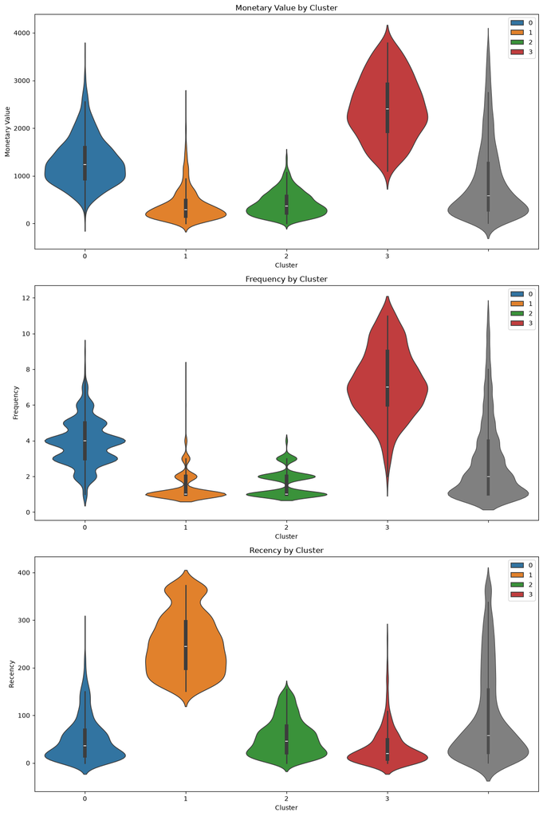

```python
plt.figure(figsize=(12, 18))

plt.subplot(3, 1, 1)
sns.violinplot(x=non_outliers_df['Cluster'], y=non_outliers_df['MonetaryValue'], palette=cluster_colors, hue=non_outliers_df["Cluster"])
sns.violinplot(y=non_outliers_df['MonetaryValue'], color='gray', linewidth=1.0)
plt.title('Monetary Value by Cluster')
plt.ylabel('Monetary Value')

plt.subplot(3, 1, 2)
sns.violinplot(x=non_outliers_df['Cluster'], y=non_outliers_df['Frequency'], palette=cluster_colors, hue=non_outliers_df["Cluster"])
sns.violinplot(y=non_outliers_df['Frequency'], color='gray', linewidth=1.0)
plt.title('Frequency by Cluster')
plt.ylabel('Frequency')


plt.subplot(3, 1, 3)
sns.violinplot(x=non_outliers_df['Cluster'], y=non_outliers_df['RecencyValue'], palette=cluster_colors, hue=non_outliers_df["Cluster"])
sns.violinplot(y=non_outliers_df['RecencyValue'], color='gray', linewidth=1.0)
plt.title('Recency by Cluster')
plt.ylabel('Recency')

plt.tight_layout()
plt.show()
```

With this information we need to get names of these clusters.

1. Cluster 0 (Blue): "Retain"
- Rationale: This cluster represents high-value customers who purchase regularly, though not always very recently. The focus should be on retention efforts to maintain their loyalty and spending levels.
- Action: Implement loyalty programs, personalized offers, and regular engagement to ensure they remain active.
2. Cluster 1 (Orange): "Re-Engage"
- Rationale: This group includes lower-value, infrequent buyers who haven’t purchased recently. The focus should be on re-engagement to bring them back into active purchasing behavior.
- Action: Use targeted marketing campaigns, special discounts, or reminders to encourage them to return and purchase again.
3. Cluster 2 (Green): "Nurture"
- Rationale: This cluster represents the least active and lowest-value customers, but they have made recent purchases. These customers may be new or need nurturing to increase their engagement and spending.
- Action: Focus on building relationships, providing excellent customer service, and offering incentives to encourage more frequent purchases.
4. Cluster 3 (Red): "Reward"
- Rationale: This cluster includes high-value, very frequent buyers, many of whom are still actively purchasing. They are your most loyal customers, and rewarding their loyalty is key to maintaining their engagement.
- Action: Implement a robust loyalty program, provide exclusive offers, and recognize their loyalty to keep them engaged and satisfied.

**Summary of Cluster Names:**

- Cluster 0 (Blue): "Retain"
- Cluster 1 (Orange): "Re-Engage"
- Cluster 2 (Green): "Nurture"
- Cluster 3 (Red): "Reward"

### OUTLIERS ANALYSIS

```python
overlap_indices = M_outliers.index.intersection(F_outliers.index)
```

```python
overlap_indices
```

```
Index([  65,   84,   85,   92,  126,  145,  164,  179,  202,  203,
       ...
       4107, 4125, 4143, 4156, 4200, 4235, 4236, 4237, 4241, 4262],
      dtype='int64', length=226)
```

```python
monetary_only_outliers = M_outliers.drop(overlap_indices)
frequency_only_outliers = F_outliers.drop(overlap_indices)

monetary_and_frequency_outliers = M_outliers.loc[overlap_indices]
```

```python
# Now we will manually assign cluster labels for these.

monetary_only_outliers['Cluster'] = -1
frequency_only_outliers["Cluster"] = -2
monetary_and_frequency_outliers["Cluster"] = -3
```

```python
outlier_clusters_df = pd.concat([monetary_only_outliers, frequency_only_outliers, monetary_and_frequency_outliers])
```

```python
outlier_clusters_df
```

|  | Customer ID | MonetaryValue | Frequency | LastInvoiceDate | RecencyValue | Cluster |
| --- | --- | --- | --- | --- | --- | --- |
| 9 | 12357.0 | 11229.99 | 1 | 2010-11-16 10:05:00 | 23 | -1 |
| 25 | 12380.0 | 4782.84 | 4 | 2010-08-31 14:54:00 | 100 | -1 |
| 42 | 12409.0 | 12346.62 | 4 | 2010-10-15 10:24:00 | 55 | -1 |
| 48 | 12415.0 | 19468.84 | 4 | 2010-11-29 15:07:00 | 10 | -1 |
| 61 | 12431.0 | 4145.52 | 11 | 2010-12-01 10:03:00 | 8 | -1 |
| ... | ... | ... | ... | ... | ... | ... |
| 4235 | 18223.0 | 7516.31 | 12 | 2010-11-17 12:20:00 | 22 | -3 |
| 4236 | 18225.0 | 7545.14 | 15 | 2010-12-09 15:46:00 | 0 | -3 |
| 4237 | 18226.0 | 6650.83 | 15 | 2010-11-26 15:51:00 | 13 | -3 |
| 4241 | 18231.0 | 4791.80 | 23 | 2010-10-29 14:17:00 | 41 | -3 |
| 4262 | 18260.0 | 7318.91 | 17 | 2010-11-30 12:25:00 | 9 | -3 |

476 rows × 6 columns

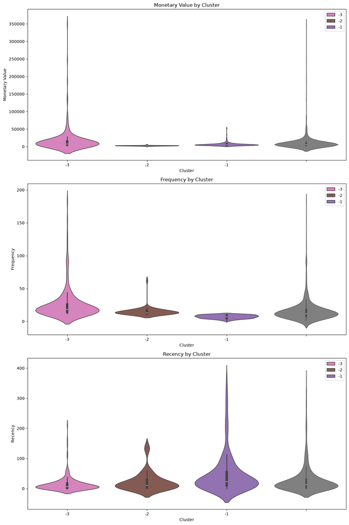

```python
cluster_colors = {-1: '#9467bd',
                  -2: '#8c564b',
                  -3: '#e377c2'}

plt.figure(figsize=(12, 18))

plt.subplot(3, 1, 1)
sns.violinplot(x=outlier_clusters_df['Cluster'], y=outlier_clusters_df['MonetaryValue'], palette=cluster_colors, hue=outlier_clusters_df["Cluster"])
sns.violinplot(y=outlier_clusters_df['MonetaryValue'], color='gray', linewidth=1.0)
plt.title('Monetary Value by Cluster')
plt.ylabel('Monetary Value')

plt.subplot(3, 1, 2)
sns.violinplot(x=outlier_clusters_df['Cluster'], y=outlier_clusters_df['Frequency'], palette=cluster_colors, hue=outlier_clusters_df["Cluster"])
sns.violinplot(y=outlier_clusters_df['Frequency'], color='gray', linewidth=1.0)
plt.title('Frequency by Cluster')
plt.ylabel('Frequency')

plt.subplot(3, 1, 3)
sns.violinplot(x=outlier_clusters_df['Cluster'], y=outlier_clusters_df['RecencyValue'], palette=cluster_colors, hue=outlier_clusters_df["Cluster"])
sns.violinplot(y=outlier_clusters_df['RecencyValue'], color='gray', linewidth=1.0)
plt.title('Recency by Cluster')
plt.ylabel('Recency')

plt.tight_layout()
plt.show()
```

Cluster -1 (Monetary Outliers) PAMPER: Characteristics: High spenders but not necessarily frequent buyers. Their purchases are large but infrequent. Potential Strategy: Focus on maintaining their loyalty with personalized offers or luxury services that cater to their high spending capacity.

Cluster -2 (Frequency Outliers) UPSELL: Characteristics: Frequent buyers who spend less per purchase. These customers are consistently engaged but might benefit from upselling opportunities. Potential Strategy: Implement loyalty programs or bundle deals to encourage higher spending per visit, given their frequent engagement.

Cluster -3 (Monetary & Frequency Outliers) DELIGHT: Characteristics: The most valuable outliers, with extreme spending and frequent purchases. They are likely your top-tier customers who require special attention. Potential Strategy: Develop VIP programs or exclusive offers to maintain their loyalty and encourage continued engagement.

```python
# Final Cluster Labels

cluster_labels = {
    0: "RETAIN",
    1: "RE-ENGAGE",
    2: "NURTURE",
    3: "REWARD",
    -1: "PAMPER",
    -2: "UPSELL",
    -3: "DELIGHT"
}
```

```python
full_clustering_df = pd.concat([non_outliers_df, outlier_clusters_df])

full_clustering_df
```

|  | Customer ID | MonetaryValue | Frequency | LastInvoiceDate | RecencyValue | Cluster |
| --- | --- | --- | --- | --- | --- | --- |
| 0 | 12346.0 | 169.36 | 2 | 2010-06-28 13:53:00 | 164 | 1 |
| 1 | 12347.0 | 1323.32 | 2 | 2010-12-07 14:57:00 | 2 | 0 |
| 2 | 12348.0 | 221.16 | 1 | 2010-09-27 14:59:00 | 73 | 2 |
| 3 | 12349.0 | 2221.14 | 2 | 2010-10-28 08:23:00 | 42 | 0 |
| 4 | 12351.0 | 300.93 | 1 | 2010-11-29 15:23:00 | 10 | 2 |
| ... | ... | ... | ... | ... | ... | ... |
| 4235 | 18223.0 | 7516.31 | 12 | 2010-11-17 12:20:00 | 22 | -3 |
| 4236 | 18225.0 | 7545.14 | 15 | 2010-12-09 15:46:00 | 0 | -3 |
| 4237 | 18226.0 | 6650.83 | 15 | 2010-11-26 15:51:00 | 13 | -3 |
| 4241 | 18231.0 | 4791.80 | 23 | 2010-10-29 14:17:00 | 41 | -3 |
| 4262 | 18260.0 | 7318.91 | 17 | 2010-11-30 12:25:00 | 9 | -3 |

4285 rows × 6 columns

```python
full_clustering_df['ClusterLabel'] = full_clustering_df["Cluster"].map(cluster_labels)

full_clustering_df
```

|  | Customer ID | MonetaryValue | Frequency | LastInvoiceDate | RecencyValue | Cluster | ClusterLabel |
| --- | --- | --- | --- | --- | --- | --- | --- |
| 0 | 12346.0 | 169.36 | 2 | 2010-06-28 13:53:00 | 164 | 1 | RE-ENGAGE |
| 1 | 12347.0 | 1323.32 | 2 | 2010-12-07 14:57:00 | 2 | 0 | RETAIN |
| 2 | 12348.0 | 221.16 | 1 | 2010-09-27 14:59:00 | 73 | 2 | NURTURE |
| 3 | 12349.0 | 2221.14 | 2 | 2010-10-28 08:23:00 | 42 | 0 | RETAIN |
| 4 | 12351.0 | 300.93 | 1 | 2010-11-29 15:23:00 | 10 | 2 | NURTURE |
| ... | ... | ... | ... | ... | ... | ... | ... |
| 4235 | 18223.0 | 7516.31 | 12 | 2010-11-17 12:20:00 | 22 | -3 | DELIGHT |
| 4236 | 18225.0 | 7545.14 | 15 | 2010-12-09 15:46:00 | 0 | -3 | DELIGHT |
| 4237 | 18226.0 | 6650.83 | 15 | 2010-11-26 15:51:00 | 13 | -3 | DELIGHT |
| 4241 | 18231.0 | 4791.80 | 23 | 2010-10-29 14:17:00 | 41 | -3 | DELIGHT |
| 4262 | 18260.0 | 7318.91 | 17 | 2010-11-30 12:25:00 | 9 | -3 | DELIGHT |

4285 rows × 7 columns

Visualization

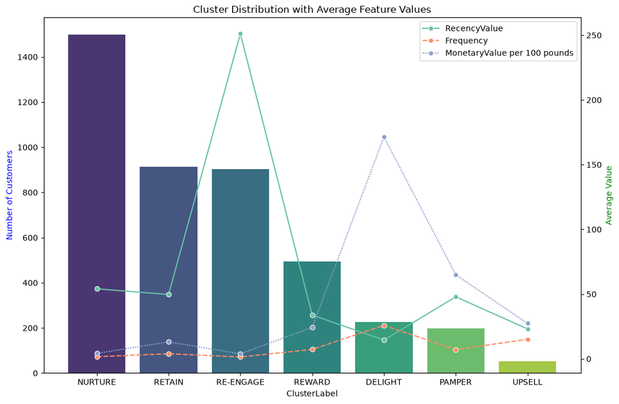

```python
cluster_counts = full_clustering_df['ClusterLabel'].value_counts()
full_clustering_df["MonetaryValue per 100 pounds"] = full_clustering_df["MonetaryValue"] / 100.00
feature_means = full_clustering_df.groupby('ClusterLabel')[['RecencyValue', 'Frequency', 'MonetaryValue per 100 pounds']].mean()

fig, ax1 = plt.subplots(figsize=(12, 8))

sns.barplot(x=cluster_counts.index, y=cluster_counts.values, ax=ax1, palette='viridis', hue=cluster_counts.index)
ax1.set_ylabel('Number of Customers', color='b')
ax1.set_title('Cluster Distribution with Average Feature Values')

ax2 = ax1.twinx()

sns.lineplot(data=feature_means, ax=ax2, palette='Set2', marker='o')
ax2.set_ylabel('Average Value', color='g')

plt.show()
```